# Simulation Challenge - Ryan Freer

Generative Models and Monte Carlo Simulation

# Game Strategy Analysis

## Problem Statement

Imagine you are offered the following game and given a $1,000 budget in a special account to play the game: I will flip a coin, and if it comes up heads, we increase your account’s balance by 50%; if it comes up tails, we reduce your account’s balance by 40%. We are not only doing this once, but we will do it once per year until you turn 55. When you turn 55, you will receive the balance in your account.

## Generative Model

The game follows this DAG model:

- **t = 1, …, N** (years until age 55)
- **Initial Wealth**: W₀ = 1000
- **Coin Flip t**: Cₜ ~ Bernoulli(0.5)
- **Wealth t**:
  - Wₜ = 1.5 × Wₜ₋₁ if Cₜ = 1 (heads)
  - Wₜ = 0.6 × Wₜ₋₁ if Cₜ = 0 (tails)

### Single Simulation

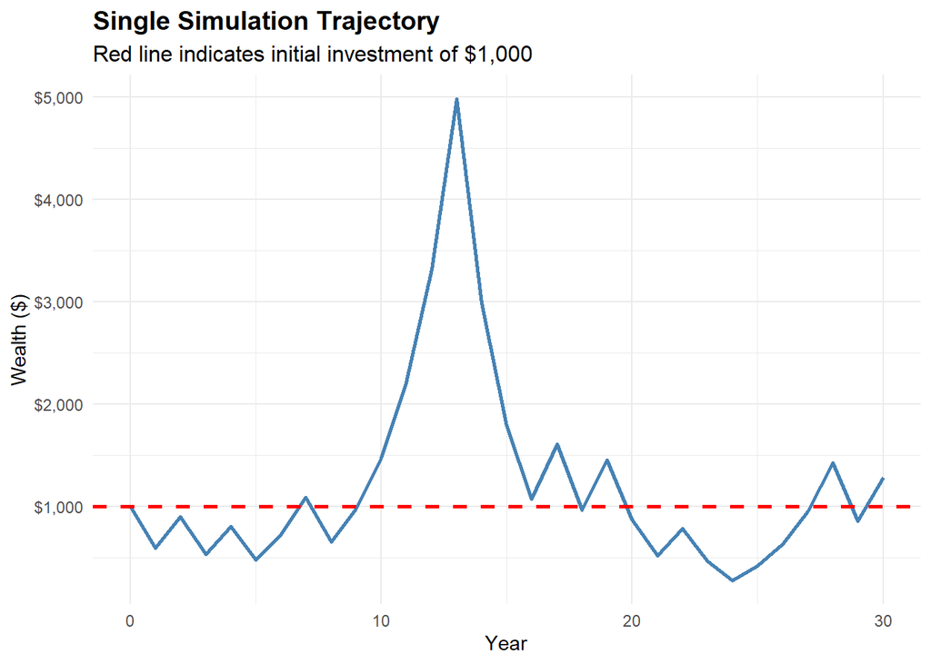

### Multiple Simulations

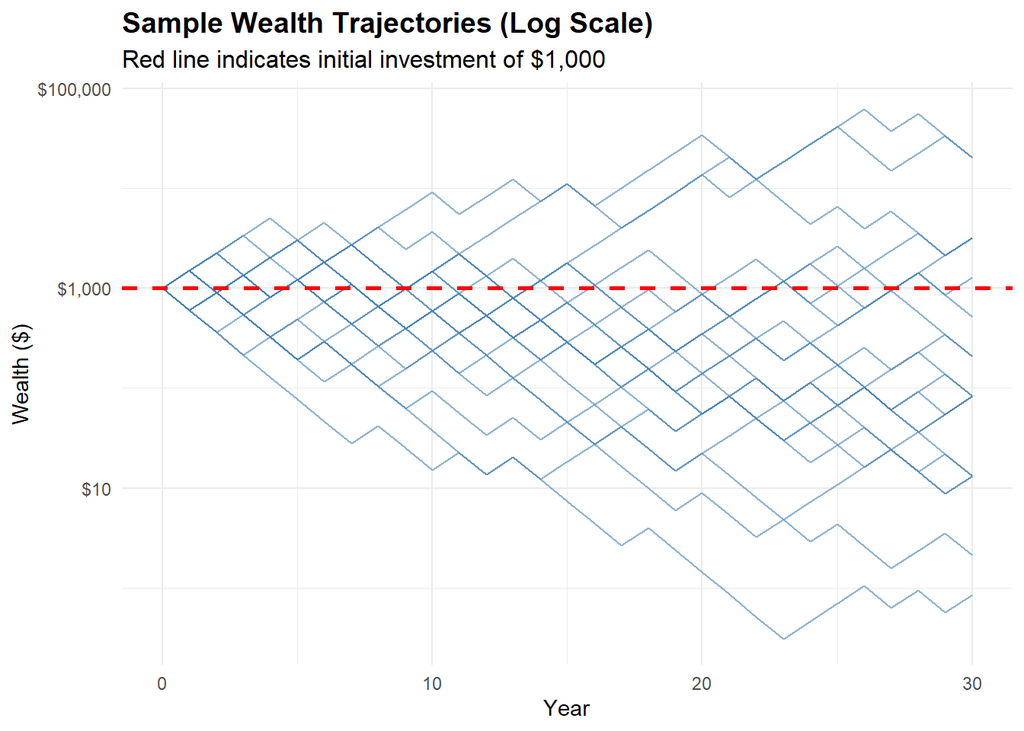

### Final Wealth Distribution

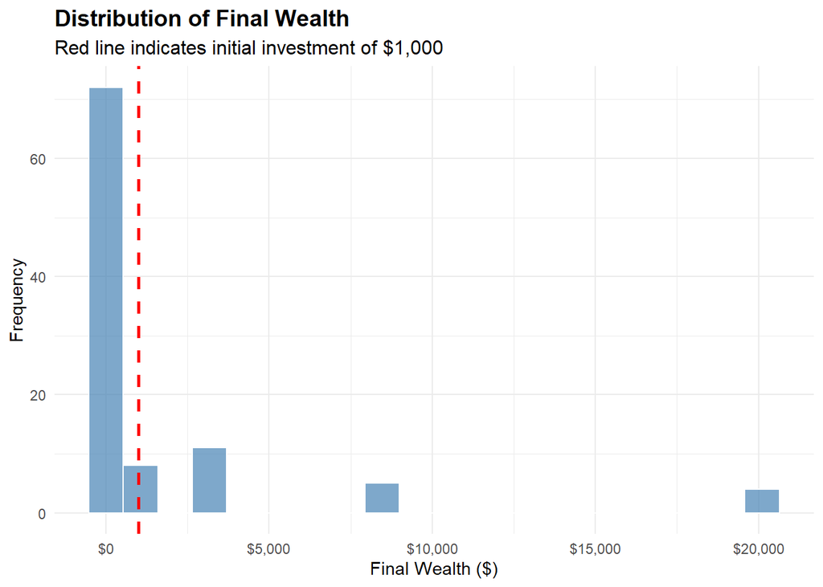

## Questions and Analysis

### Question 1: Expected Value Analysis

**What is the “expected value” of your account balance after 1 coin flip for the original game?**

```
[1] 1050
```

```
[1] 0.05
```

**Answer:** The expected value after 1 coin flip is $1,050, representing a 5% expected return. This return is small compared to the initial investment of $1000. However it is just the simulation of one flip. It is not guaranteed to be positive. We would need to run more simulations to get a more accurate representation.

### Question 2: Expectation vs. Reality

**Is the expected value positive or negative? Do you expect your account to be worth more or less than $1,000 based on this result?**

```
[1] 4321.942
```

```
[1] 0.05
```

**Answer:** The expected value is **positive**. Each year, the expected return is 5%, so after 30 years, the expected account balance would be $4,321.94. This is significantly more than the initial invesment of $1000.

### Question 3: Single Simulation

**Run one simulation showing the dynamics of your account balance over time. Make an object-oriented ggplot2 plot showing your simulated account balance over time (i.e. as you age). Comment on the results, are you happy?**

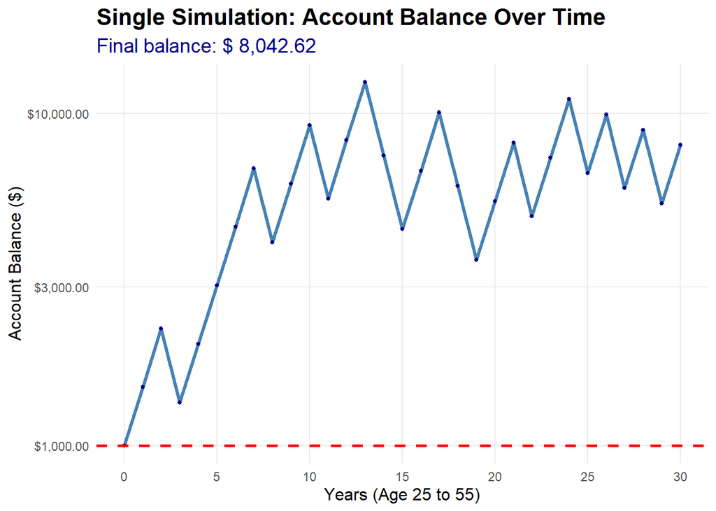

```
Final account balance: $ 8,042.62
```

```
Total return:  704.3 %
```

**Analysis:** The single simulation shows an extremely positive return, but the return is not guaranteed. It is possible to lose money as seen in the next question with 100 simulations. The expected value is positive, but the return is not guaranteed wiht many outliers like this one that will prop up the mean balance.

### Question 4: Multiple Simulations

**Run 100 simulations modelling the dynamics of your account balance over time. Make an object-oriented ggplot2 plot showing a probability distribution of the 100 simulated account balance at age 55. Comment on the results, are you happy? Why or why not?**

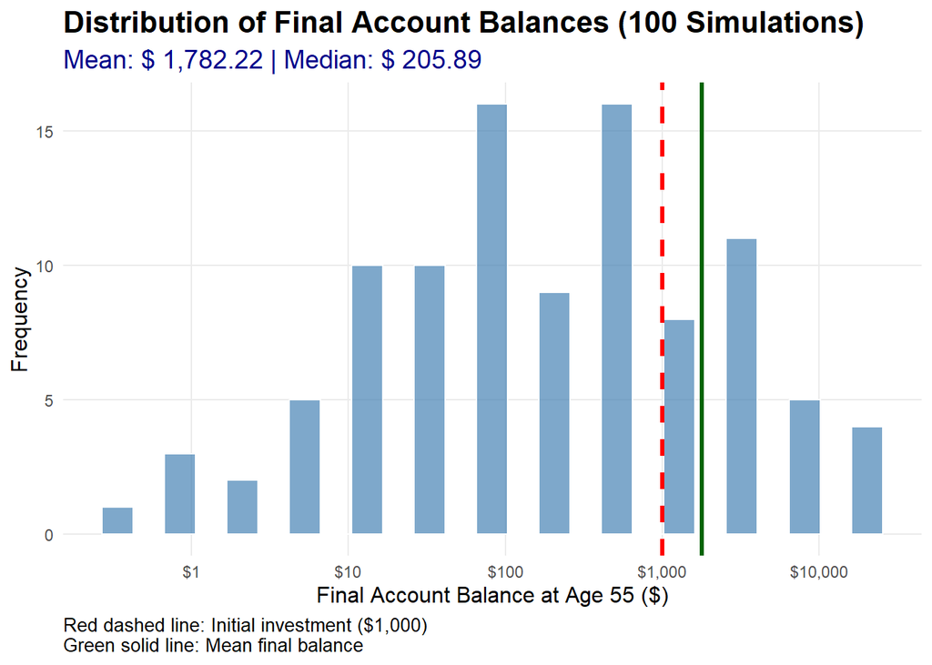

```
Summary Statistics (100 Simulations):
```

```
Mean final balance: $ 1,782.22
```

```
Median final balance: $ 205.89
```

```
Standard deviation: $ 4,210.03
```

```
Minimum final balance: $ 0.34
```

```
Maximum final balance: $ 20,106.56
```

**Analysis:** The mean balance is higher than the initial investment of $1000. However, there are many outliers that are much higher than the mean. This is evident by seing how low the median balance is compared to the mean. It is likely that one will end up with a balance much lower than the mean, and lower than the initial investment of $1000.

### Question 5: Probability Analysis

**Based on the 100 simulations above, what is the probability that your account balance will be greater than $1,000 at age 55?**

Probability Analysis of Final Account Balances

| Condition | Probability | Percentage |
| --- | --- | --- |
| Greater than $1,000 | 0.28 | 28% |
| Less than $1,000 | 0.72 | 72% |
| Equal to $1,000 | 0 | 0% |
| Greater than $5,000 | 0.09 | 9% |
| Greater than $10,000 | 0.04 | 4% |
| Less than $100 | 0.47 | 47% |

```
Key Result: The probability of ending with more than $1,000 is  28 %
```